# LME Analysis of PNs

Antoin Rodgers

18.05.2022

## H targets

### Analysis of H timing

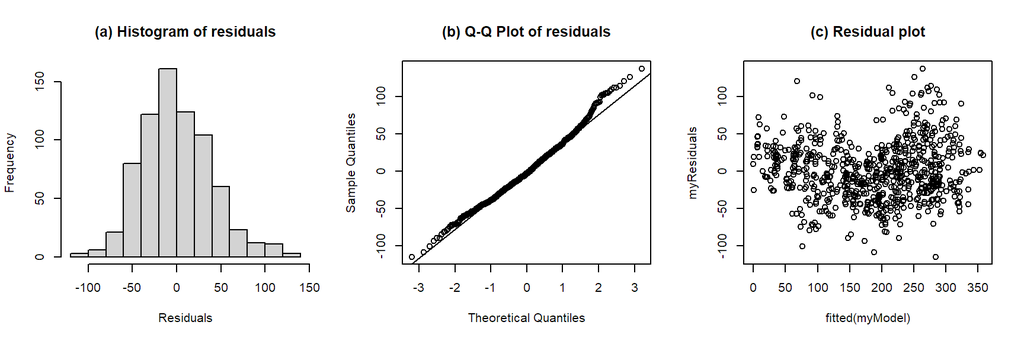

```
## Formula:  h_t ~ acc_phon + ana_syls + foot_syls + pn_new_word + wrd_end_syl + gender + (1 | speaker) + (1 | ana_text) + (1 | foot_dur)
##
## Linear mixed model fit by REML. t-tests use Satterthwaite's method [
## lmerModLmerTest]
## Formula: h_t_equation
##    Data: pn_h_t.trimmed
## Control:
## lmerControl(optimizer = optimizer, calc.derivs = FALSE, optCtrl = list(method = "nlminb",
##     starttests = FALSE, kkt = FALSE))
##
## REML criterion at convergence: 7504.6
##
## Scaled residuals:
##     Min      1Q  Median      3Q     Max
## -2.7761 -0.6554 -0.0755  0.6015  3.3232
##
## Random effects:
##  Groups   Name        Variance Std.Dev.
##  foot_dur (Intercept)  130.4   11.42
##  speaker  (Intercept)  518.0   22.76
##  ana_text (Intercept)  369.4   19.22
##  Residual             1694.9   41.17
## Number of obs: 730, groups:  foot_dur, 396; speaker, 11; ana_text, 7
##
## Fixed effects:
##              Estimate Std. Error      df t value Pr(>|t|)
## (Intercept)   186.215     32.165   2.162   5.789 0.023810 *
## acc_phon>H*   -34.871      6.833 708.675  -5.103 4.29e-07 ***
## acc_phonH*    -78.130      5.371 716.440 -14.547  < 2e-16 ***
## ana_syls1     -34.226     27.814   1.657  -1.231 0.364863
## ana_syls2      38.099     36.580   1.779   1.042 0.418336
## ana_syls3      51.213     36.578   1.779   1.400 0.310437
## foot_syls2     31.087      6.186 663.959   5.025 6.47e-07 ***
## foot_syls3     53.125      7.397 699.828   7.182 1.76e-12 ***
## foot_syls4     67.592      8.401 690.746   8.046 3.73e-15 ***
## pn_new_word0   42.422     23.686   1.951   1.791 0.218296
## wrd_end_syl2  -13.051      5.916 701.708  -2.206 0.027711 *
## wrd_end_syl3   14.396      9.767 703.437   1.474 0.140932
## genderM       -74.004     14.216   9.127  -5.206 0.000535 ***
## ---
```

[output cut: 16 more lines]

```
##
##             Eliminated Sum Sq Mean Sq NumDF  DenDF  F value    Pr(>F)
## pn_new_word          1   5437    5437     1   1.95   3.2078 0.2182962
## ana_syls             2  18432    6144     3   2.69   3.6285 0.1750340
## acc_phon             0 362858  181429     2 714.17 107.1923 < 2.2e-16 ***
## foot_syls            0 127913   42638     3 699.90  25.1913 1.743e-15 ***
## wrd_end_syl          0  28958   14479     2 705.90   8.5545 0.0002134 ***
## gender               0  45763   45763     1   9.13  27.0378 0.0005391 ***
## ---
## Signif. codes:  0 '***' 0.001 '**' 0.01 '*' 0.05 '.' 0.1 ' ' 1
##
## Model found:
## h_t ~ acc_phon + foot_syls + wrd_end_syl + gender + (1 | speaker) + (1 | ana_text) + (1 | foot_dur)
##
## isSingular(my_model, tol = 1e-05 ) --> FALSE
```

Anova of model: h_t ~ acc_phon + ana_syls + foot_syls + pn_new_word + wrd_end_syl + gender + (1 | speaker) + (1 | ana_text) + (1 | foot_dur)

| term | sumsq | meansq | NumDF | DenDF | F value | p.value | signif. |
| --- | --- | --- | --- | --- | --- | --- | --- |
| acc_phon | 359188.914 | 179594.457 | 2 | 713.698 | 105.962 | 5.070323e-41 | p<0.001 |
| ana_syls | 31961.776 | 10653.925 | 3 | 2.000 | 6.286 | 1.403273e-01 |  |
| foot_syls | 125844.882 | 41948.294 | 3 | 687.241 | 24.750 | 3.244314e-15 | p<0.001 |
| pn_new_word | 5436.845 | 5436.845 | 1 | 1.951 | 3.208 | 2.182962e-01 |  |
| wrd_end_syl | 28982.687 | 14491.344 | 2 | 704.554 | 8.550 | 2.143597e-04 | p<0.001 |
| gender | 45931.411 | 45931.411 | 1 | 9.127 | 27.100 | 5.349746e-04 | p<0.001 |

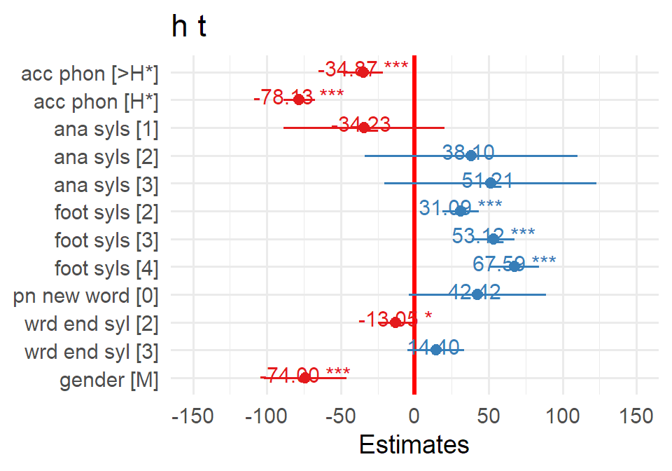

Conditional and marginal R<sup>2</sup> of model

| R2_conditional | R2_marginal |
| --- | --- |
| 0.82 | 0.72 |

$acc_phon

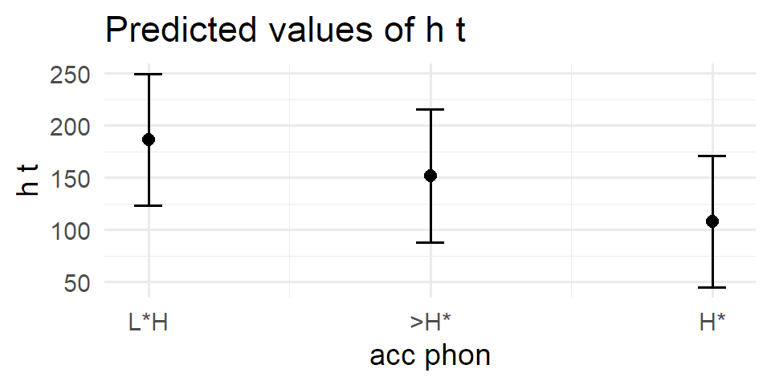

$ana_syls

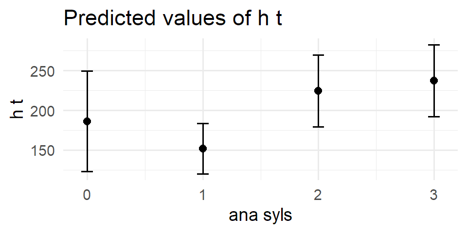

$foot_syls

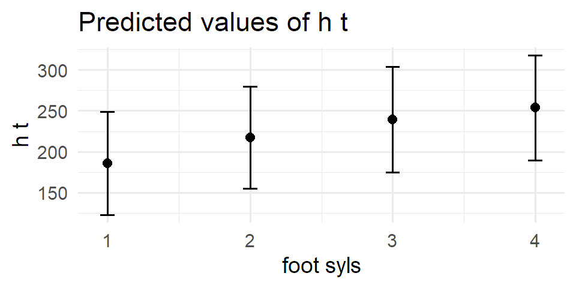

$pn_new_word

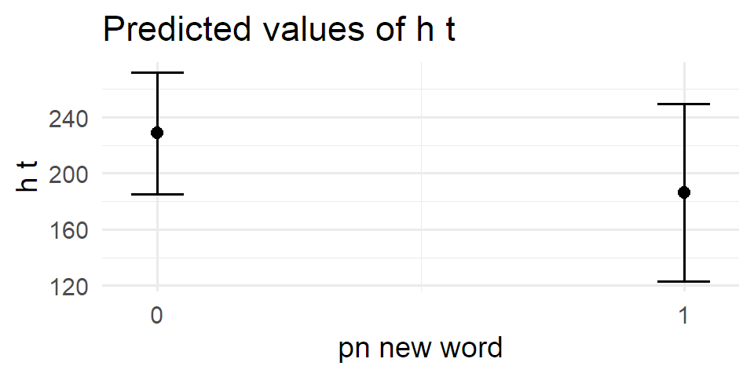

$wrd_end_syl

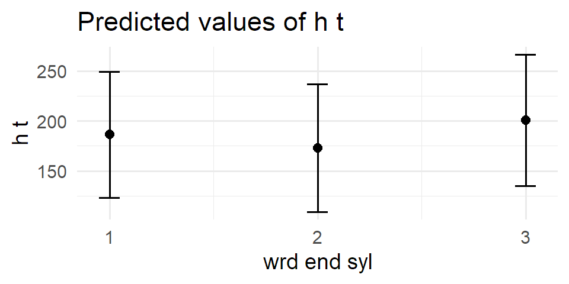

$gender

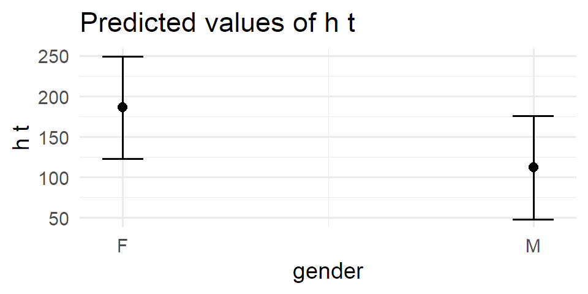

summary of model: h_t ~ acc_phon + ana_syls + foot_syls + pn_new_word + wrd_end_syl + gender + (1 | speaker) + (1 | ana_text) + (1 | foot_dur)

| term | estimate | conf.low | conf.high | std.error | t.value | df | p.value |
| --- | --- | --- | --- | --- | --- | --- | --- |
| (Intercept) | 186.215 | 57.281014 | 315.149170 | 32.165 | 5.789 | 2.16 | 0.0238 |
| acc_phon>H* | -34.871 | -48.286411 | -21.456202 | 6.833 | -5.103 | 708.68 | 4.3e-07 |
| acc_phonH* | -78.130 | -88.674179 | -67.585336 | 5.371 | -14.547 | 716.44 | 3.4e-42 |
| ana_syls1 | -34.226 | -181.103417 | 112.651577 | 27.814 | -1.231 | 1.66 | 0.3649 |
| ana_syls2 | 38.099 | -139.554737 | 215.751981 | 36.580 | 1.042 | 1.78 | 0.4183 |
| ana_syls3 | 51.213 | -126.462682 | 228.889193 | 36.578 | 1.400 | 1.78 | 0.3104 |
| foot_syls2 | 31.087 | 18.940594 | 43.233442 | 6.186 | 5.025 | 663.96 | 6.5e-07 |
| foot_syls3 | 53.125 | 38.601852 | 67.647576 | 7.397 | 7.182 | 699.83 | 1.8e-12 |
| foot_syls4 | 67.592 | 51.097482 | 84.085610 | 8.401 | 8.046 | 690.75 | 3.7e-15 |
| pn_new_word0 | 42.422 | -61.963767 | 146.807578 | 23.686 | 1.791 | 1.95 | 0.2183 |
| wrd_end_syl2 | -13.051 | -24.666162 | -1.435203 | 5.916 | -2.206 | 701.71 | 0.0277 |
| wrd_end_syl3 | 14.396 | -4.779507 | 33.572309 | 9.767 | 1.474 | 703.44 | 0.1409 |
| genderM | -74.004 | -106.094068 | -41.913593 | 14.216 | -5.206 | 9.13 | 5e-04 |

b0 for h_t ~ acc_phon + ana_syls + foot_syls + pn_new_word + wrd_end_syl + gender + (1 | speaker) + (1 | ana_text) + (1 | foot_dur)

| intercept | estimate | conf.low | conf.high | std.error | t.value | df | p.value |
| --- | --- | --- | --- | --- | --- | --- | --- |
| acc_phonL*H | 186.2 | 57.3 | 315.1 | 32.165 | 5.789 | 2.16 | 0.024 |
| acc_phon>H* | 151.3 | 26.1 | 276.6 | 32.556 | 4.649 | 2.27 | 0.034 |
| acc_phonH* | 108.1 | -21 | 237.1 | 32.138 | 3.363 | 2.16 | 0.07 |
| ana_syls0 | 186.2 | 57.3 | 315.1 | 32.165 | 5.789 | 2.16 | 0.024 |
| ana_syls1 | 152 | 112.5 | 191.5 | 16.164 | 9.403 | 6.02 | 8.0e-05 |
| ana_syls2 | 224.3 | 151.9 | 296.8 | 22.977 | 9.763 | 3.05 | 0.002 |
| ana_syls3 | 237.4 | 165 | 309.9 | 22.982 | 10.331 | 3.05 | 0.002 |
| foot_syls1 | 186.2 | 57.3 | 315.1 | 32.165 | 5.789 | 2.16 | 0.024 |
| foot_syls2 | 217.3 | 85.3 | 349.3 | 31.837 | 6.825 | 2.08 | 0.019 |
| foot_syls3 | 239.3 | 117.6 | 361.1 | 32.975 | 7.258 | 2.39 | 0.011 |
| foot_syls4 | 253.8 | 129.3 | 378.3 | 32.644 | 7.775 | 2.29 | 0.011 |
| wrd_end_syl1 | 186.2 | 57.3 | 315.1 | 32.165 | 5.789 | 2.16 | 0.024 |
| wrd_end_syl2 | 173.2 | 47.9 | 298.4 | 32.559 | 5.319 | 2.27 | 0.025 |
| wrd_end_syl3 | 200.6 | 82.5 | 318.7 | 33.508 | 5.987 | 2.55 | 0.015 |

b1 for h_t ~ acc_phon + ana_syls + foot_syls + pn_new_word + wrd_end_syl + gender + (1 | speaker) + (1 | ana_text) + (1 | foot_dur)

| intercept | slope | estimate | conf.low | conf.high | std.error | t.value | df | p.value |
| --- | --- | --- | --- | --- | --- | --- | --- | --- |
| acc_phonL*H | acc_phon>H* | -34.9 | -48.3 | -21.5 | 6.833 | -5.103 | 708.68 | 4.3e-07 |
| acc_phonL*H | acc_phonH* | -78.1 | -88.7 | -67.6 | 5.371 | -14.547 | 716.44 | 3.4e-42 |
| acc_phon>H* | acc_phonH* | -43.3 | -57.5 | -29 | 7.241 | -5.974 | 708.62 | 3.7e-09 |
| ana_syls0 | ana_syls1 | -34.2 | -181.1 | 112.7 | 27.814 | -1.231 | 1.66 | 0.365 |
| ana_syls0 | ana_syls2 | 38.1 | -139.6 | 215.8 | 36.580 | 1.042 | 1.78 | 0.418 |
| ana_syls0 | ana_syls3 | 51.2 | -126.5 | 228.9 | 36.578 | 1.400 | 1.78 | 0.31 |
| ana_syls1 | ana_syls2 | 72.3 | -31.4 | 176 | 23.756 | 3.044 | 1.97 | 0.095 |
| ana_syls1 | ana_syls3 | 85.4 | -18.3 | 189.2 | 23.753 | 3.597 | 1.97 | 0.071 |
| ana_syls2 | ana_syls3 | 13.1 | -123.8 | 150 | 28.353 | 0.463 | 1.79 | 0.694 |
| foot_syls1 | foot_syls2 | 31.1 | 18.9 | 43.2 | 6.186 | 5.025 | 663.96 | 6.5e-07 |
| foot_syls1 | foot_syls3 | 53.1 | 38.6 | 67.6 | 7.397 | 7.182 | 699.83 | 1.8e-12 |
| foot_syls1 | foot_syls4 | 67.6 | 51.1 | 84.1 | 8.401 | 8.046 | 690.75 | 3.7e-15 |
| foot_syls2 | foot_syls3 | 22 | 7.942 | 36.1 | 7.179 | 3.070 | 704.38 | 0.002 |
| foot_syls2 | foot_syls4 | 36.5 | 20.1 | 52.9 | 8.336 | 4.379 | 684.19 | 1.4e-05 |
| foot_syls3 | foot_syls4 | 14.5 | 0.914 | 28 | 6.903 | 2.096 | 707.51 | 0.036 |
| wrd_end_syl1 | wrd_end_syl2 | -13.1 | -24.7 | -1.435 | 5.916 | -2.206 | 701.71 | 0.028 |
| wrd_end_syl1 | wrd_end_syl3 | 14.4 | -4.78 | 33.6 | 9.767 | 1.474 | 703.44 | 0.141 |
| wrd_end_syl2 | wrd_end_syl3 | 27.4 | 12.1 | 42.8 | 7.813 | 3.513 | 708.14 | 4.7e-04 |
| intercept | pn_new_word0 | 42.4 | -62 | 146.8 | 23.686 | 1.791 | 1.95 | 0.218 |

### Analysis of H F0

- model dosn’t work with SR, ana_end_t, or foot_dur (and suggested to be removed by step())

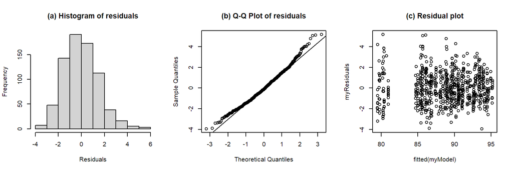

```
## Formula:  h_f0 ~ acc_phon + ana_syls + foot_syls + wrd_end_syl + pn_new_word + (1 | speaker) + (1 | ana_text)
##
## Linear mixed model fit by REML. t-tests use Satterthwaite's method [
## lmerModLmerTest]
## Formula: h_f0_equation
##    Data: pn_h_data
## Control:
## lmerControl(optimizer = optimizer, calc.derivs = FALSE, optCtrl = list(method = "nlminb",
##     starttests = FALSE, kkt = FALSE))
##
## REML criterion at convergence: 2769.4
##
## Scaled residuals:
##     Min      1Q  Median      3Q     Max
## -2.6069 -0.6993 -0.0821  0.6211  3.4298
##
## Random effects:
##  Groups   Name        Variance Std.Dev.
##  speaker  (Intercept) 16.9755  4.120
##  ana_text (Intercept)  0.1632  0.404
##  Residual              2.2726  1.508
## Number of obs: 737, groups:  speaker, 11; ana_text, 7
##
## Fixed effects:
##               Estimate Std. Error        df t value Pr(>|t|)
## (Intercept)   87.72255    1.42381  10.42536  61.611 1.06e-14 ***
## acc_phon>H*    0.09801    0.24172 715.08004   0.405  0.68525
## acc_phonH*     0.04365    0.18962 714.50945   0.230  0.81798
## ana_syls1      0.61523    0.60663   1.21302   1.014  0.47072
## ana_syls2      0.76232    0.81886   1.42851   0.931  0.48188
## ana_syls3      0.05733    0.81957   1.43329   0.070  0.95271
## foot_syls2     0.27648    0.21549 471.63267   1.283  0.20010
## foot_syls3     0.81448    0.25638 714.41619   3.177  0.00155 **
## foot_syls4     0.71490    0.29233 712.96984   2.445  0.01471 *
## wrd_end_syl2   0.04724    0.20612 713.15019   0.229  0.81879
## wrd_end_syl3   0.51569    0.34349 714.80514   1.501  0.13372
## pn_new_word0   0.58318    0.54611   1.74796   1.068  0.41082
## ---
## Signif. codes:  0 '***' 0.001 '**' 0.01 '*' 0.05 '.' 0.1 ' ' 1
##
```

[output cut: 38 more lines]

```
## Degrees of freedom method: Satterthwaite
##
##             Eliminated Sum Sq Mean Sq NumDF  DenDF F value    Pr(>F)
## acc_phon             1  0.778  0.3888     2 715.74  0.1699  0.843805
## wrd_end_syl          2  7.319  3.6593     2 717.03  1.6027  0.202078
## ana_syls             0 37.559 12.5198     3 719.00  5.4742  0.001008 **
## foot_syls            0 48.982 16.3274     3 719.02  7.1390 9.945e-05 ***
## pn_new_word          0 14.415 14.4145     1 719.01  6.3027  0.012274 *
## ---
## Signif. codes:  0 '***' 0.001 '**' 0.01 '*' 0.05 '.' 0.1 ' ' 1
##
## Model found:
## h_f0 ~ ana_syls + foot_syls + pn_new_word + (1 | speaker)
##
## isSingular(my_model, tol = 1e-05 ) --> FALSE
```

Anova of model: h_f0 ~ acc_phon + ana_syls + foot_syls + wrd_end_syl + pn_new_word + (1 | speaker) + (1 | ana_text)

| term | sumsq | meansq | NumDF | DenDF | F value | p.value | signif. |
| --- | --- | --- | --- | --- | --- | --- | --- |
| acc_phon | 0.400 | 0.200 | 2 | 715.719 | 0.088 | 0.9156877 |  |
| ana_syls | 5.575 | 1.858 | 3 | 2.000 | 0.818 | 0.5911400 |  |
| foot_syls | 23.930 | 7.977 | 3 | 621.451 | 3.510 | 0.0151037 | p<0.05 |
| wrd_end_syl | 6.691 | 3.345 | 2 | 714.121 | 1.472 | 0.2301582 |  |
| pn_new_word | 2.592 | 2.592 | 1 | 1.748 | 1.140 | 0.4108221 |  |

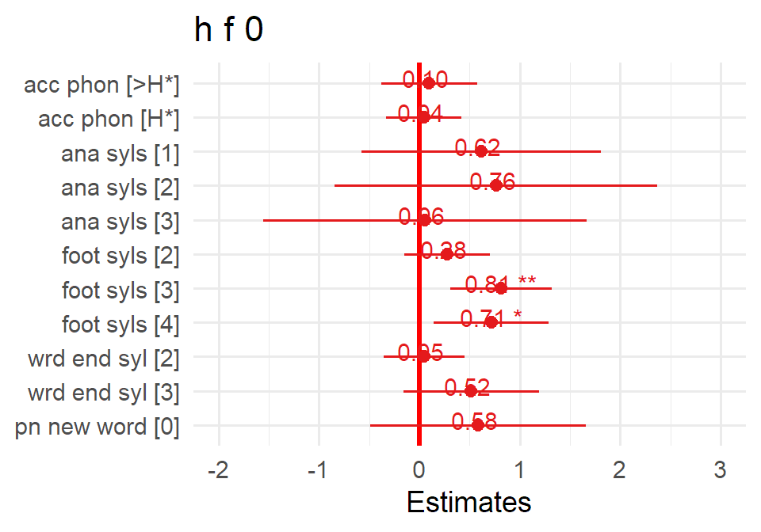

Conditional and marginal R<sup>2</sup> of model

| R2_conditional | R2_marginal |
| --- | --- |
| 0.88 | 0.01 |

$acc_phon

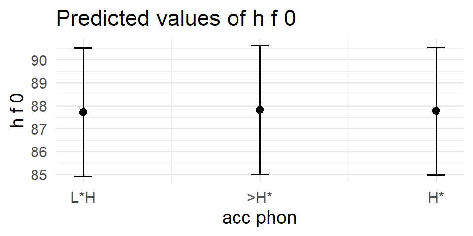

$ana_syls

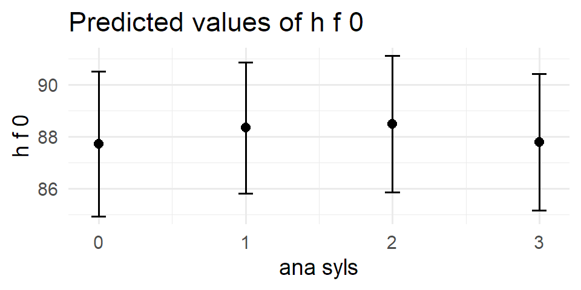

$foot_syls

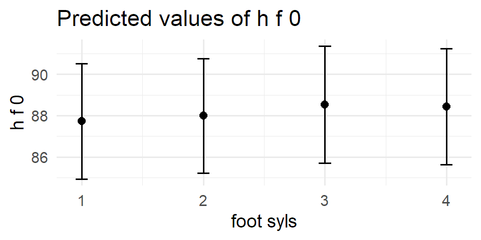

$wrd_end_syl

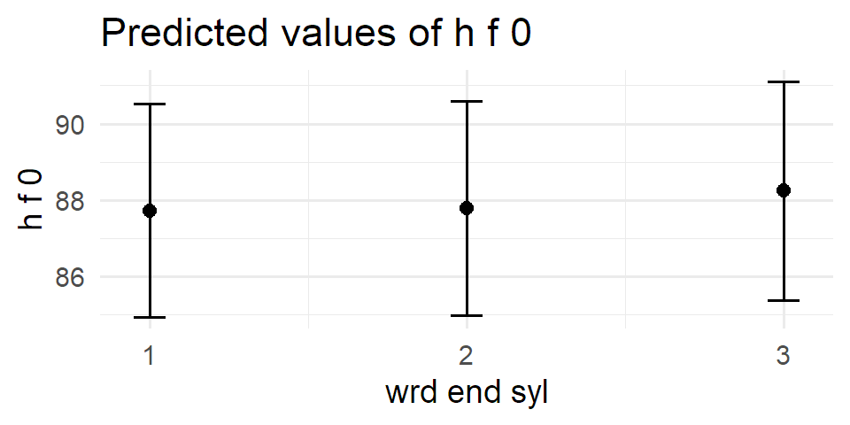

$pn_new_word

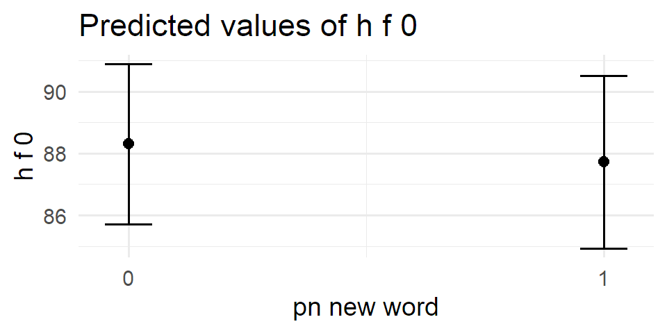

summary of model: h_f0 ~ acc_phon + ana_syls + foot_syls + wrd_end_syl + pn_new_word + (1 | speaker) + (1 | ana_text)

| term | estimate | conf.low | conf.high | std.error | t.value | df | p.value |
| --- | --- | --- | --- | --- | --- | --- | --- |
| (Intercept) | 87.723 | 84.5675535 | 90.8775488 | 1.424 | 61.611 | 10.43 | 1.1e-14 |
| acc_phon>H* | 0.098 | -0.3765602 | 0.5725860 | 0.242 | 0.405 | 715.08 | 0.6852 |
| acc_phonH* | 0.044 | -0.3286172 | 0.4159252 | 0.190 | 0.230 | 714.51 | 0.818 |
| ana_syls1 | 0.615 | -4.5271088 | 5.7575712 | 0.607 | 1.014 | 1.21 | 0.4707 |
| ana_syls2 | 0.762 | -4.5250557 | 6.0496945 | 0.819 | 0.931 | 1.43 | 0.4819 |
| ana_syls3 | 0.057 | -5.2083236 | 5.3229815 | 0.820 | 0.070 | 1.43 | 0.9527 |
| foot_syls2 | 0.276 | -0.1469487 | 0.6999138 | 0.215 | 1.283 | 471.63 | 0.2001 |
| foot_syls3 | 0.814 | 0.3111418 | 1.3178222 | 0.256 | 3.177 | 714.42 | 0.0016 |
| foot_syls4 | 0.715 | 0.1409627 | 1.2888384 | 0.292 | 2.445 | 712.97 | 0.0147 |
| wrd_end_syl2 | 0.047 | -0.3574329 | 0.4519095 | 0.206 | 0.229 | 713.15 | 0.8188 |
| wrd_end_syl3 | 0.516 | -0.1586835 | 1.1900657 | 0.343 | 1.501 | 714.81 | 0.1337 |
| pn_new_word0 | 0.583 | -2.1230351 | 3.2893917 | 0.546 | 1.068 | 1.75 | 0.4108 |

b0 for h_f0 ~ acc_phon + ana_syls + foot_syls + wrd_end_syl + pn_new_word + (1 | speaker) + (1 | ana_text)

| intercept | estimate | conf.low | conf.high | std.error | t.value | df | p.value |
| --- | --- | --- | --- | --- | --- | --- | --- |
| acc_phonL*H | 87.7 | 84.6 | 90.9 | 1.424 | 61.611 | 10.43 | 1.1e-14 |
| acc_phon>H* | 87.8 | 84.7 | 91 | 1.434 | 61.247 | 10.74 | 5.2e-15 |
| acc_phonH* | 87.8 | 84.6 | 90.9 | 1.421 | 61.780 | 10.36 | 1.2e-14 |
| ana_syls0 | 87.7 | 84.6 | 90.9 | 1.424 | 61.611 | 10.43 | 1.1e-14 |
| ana_syls1 | 88.3 | 85.5 | 91.2 | 1.288 | 68.570 | 11.35 | 3.2e-16 |
| ana_syls2 | 88.5 | 85.6 | 91.4 | 1.340 | 66.041 | 12.08 | 7.9e-17 |
| ana_syls3 | 87.8 | 84.9 | 90.7 | 1.340 | 65.493 | 12.10 | 8.4e-17 |
| foot_syls1 | 87.7 | 84.6 | 90.9 | 1.424 | 61.611 | 10.43 | 1.1e-14 |
| foot_syls2 | 88 | 84.9 | 91.1 | 1.416 | 62.146 | 10.27 | 1.4e-14 |
| foot_syls3 | 88.5 | 85.4 | 91.7 | 1.445 | 61.272 | 11.10 | 2.1e-15 |
| foot_syls4 | 88.4 | 85.3 | 91.6 | 1.435 | 61.608 | 10.78 | 4.4e-15 |
| wrd_end_syl1 | 87.7 | 84.6 | 90.9 | 1.424 | 61.611 | 10.43 | 1.1e-14 |
| wrd_end_syl2 | 87.8 | 84.6 | 90.9 | 1.435 | 61.178 | 10.75 | 5.1e-15 |
| wrd_end_syl3 | 88.2 | 85 | 91.4 | 1.463 | 60.325 | 11.65 | 6.6e-16 |

b1 for h_f0 ~ acc_phon + ana_syls + foot_syls + wrd_end_syl + pn_new_word + (1 | speaker) + (1 | ana_text)

| intercept | slope | estimate | conf.low | conf.high | std.error | t.value | df | p.value |
| --- | --- | --- | --- | --- | --- | --- | --- | --- |
| acc_phonL*H | acc_phon>H* | 0.098 | -0.377 | 0.573 | 0.242 | 0.405 | 715.08 | 0.685 |
| acc_phonL*H | acc_phonH* | 0.044 | -0.329 | 0.416 | 0.190 | 0.230 | 714.51 | 0.818 |
| acc_phon>H* | acc_phonH* | -0.054 | -0.557 | 0.449 | 0.256 | -0.212 | 714.24 | 0.832 |
| ana_syls0 | ana_syls1 | 0.615 | -4.527 | 5.758 | 0.607 | 1.014 | 1.21 | 0.471 |
| ana_syls0 | ana_syls2 | 0.762 | -4.525 | 6.05 | 0.819 | 0.931 | 1.43 | 0.482 |
| ana_syls0 | ana_syls3 | 0.057 | -5.208 | 5.323 | 0.820 | 0.070 | 1.43 | 0.953 |
| ana_syls1 | ana_syls2 | 0.147 | -2.524 | 2.818 | 0.550 | 0.267 | 1.78 | 0.817 |
| ana_syls1 | ana_syls3 | -0.558 | -3.212 | 2.096 | 0.551 | -1.012 | 1.79 | 0.428 |
| ana_syls2 | ana_syls3 | -0.705 | -4.573 | 3.163 | 0.639 | -1.103 | 1.49 | 0.416 |
| foot_syls1 | foot_syls2 | 0.276 | -0.147 | 0.7 | 0.215 | 1.283 | 471.63 | 0.2 |
| foot_syls1 | foot_syls3 | 0.814 | 0.311 | 1.318 | 0.256 | 3.177 | 714.42 | 0.002 |
| foot_syls1 | foot_syls4 | 0.715 | 0.141 | 1.289 | 0.292 | 2.445 | 712.97 | 0.015 |
| foot_syls2 | foot_syls3 | 0.538 | 0.049 | 1.027 | 0.249 | 2.162 | 697.73 | 0.031 |
| foot_syls2 | foot_syls4 | 0.438 | -0.128 | 1.005 | 0.289 | 1.519 | 650.78 | 0.129 |
| foot_syls3 | foot_syls4 | -0.1 | -0.573 | 0.373 | 0.241 | -0.413 | 714.96 | 0.68 |
| wrd_end_syl1 | wrd_end_syl2 | 0.047 | -0.357 | 0.452 | 0.206 | 0.229 | 713.15 | 0.819 |
| wrd_end_syl1 | wrd_end_syl3 | 0.516 | -0.159 | 1.19 | 0.343 | 1.501 | 714.81 | 0.134 |
| wrd_end_syl2 | wrd_end_syl3 | 0.468 | -0.073 | 1.01 | 0.276 | 1.699 | 714.84 | 0.09 |
| intercept | pn_new_word0 | 0.583 | -2.123 | 3.289 | 0.546 | 1.068 | 1.75 | 0.411 |

## L targets

### Analysis of L timing

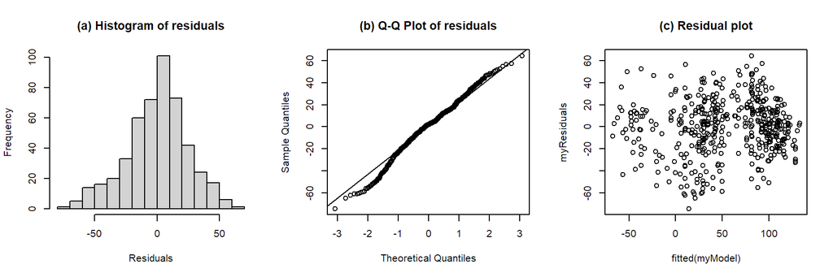

```
## Formula:  l_t ~ acc_phon + ana_syls + foot_syls + wrd_end_syl + pn_new_word + gender + (1 | speaker) + (1 | ana_text) + (1 | ana_end_t)
##
## Linear mixed model fit by REML. t-tests use Satterthwaite's method [
## lmerModLmerTest]
## Formula: l_t_equation
##    Data: pn_l_t.trimmed
## Control:
## lmerControl(optimizer = optimizer, calc.derivs = FALSE, optCtrl = list(method = "nlminb",
##     starttests = FALSE, kkt = FALSE))
##
## REML criterion at convergence: 4582.2
##
## Scaled residuals:
##      Min       1Q   Median       3Q      Max
## -2.79487 -0.54270  0.07183  0.55943  2.42152
##
## Random effects:
##  Groups    Name        Variance Std.Dev.
##  ana_end_t (Intercept) 245.1    15.65
##  speaker   (Intercept) 126.6    11.25
##  ana_text  (Intercept) 978.1    31.27
##  Residual              706.3    26.58
## Number of obs: 485, groups:  ana_end_t, 167; speaker, 11; ana_text, 7
##
## Fixed effects:
##              Estimate Std. Error       df t value Pr(>|t|)
## (Intercept)   87.5208    51.4350   1.9256   1.702 0.235718
## acc_phonL*    35.7794    10.3235 401.3639   3.466 0.000586 ***
## ana_syls1    -58.6741    47.1614   1.8614  -1.244 0.347361
## ana_syls2    -17.3509    60.0746   1.7591  -0.289 0.803137
## ana_syls3     -7.5021    60.0689   1.7584  -0.125 0.913395
## foot_syls2     8.9223     6.1144 415.3584   1.459 0.145258
## foot_syls3    15.4146     6.2201 427.4858   2.478 0.013590 *
## foot_syls4    34.5325     6.8860 462.5977   5.015 7.58e-07 ***
## wrd_end_syl2  -0.2316     4.5003 439.0859  -0.051 0.958976
## wrd_end_syl3  -7.9003     6.9352 414.9175  -1.139 0.255294
## pn_new_word0 -11.0046    37.2052   1.6107  -0.296 0.801055
## genderM      -76.1123     7.4917   9.6720 -10.160 1.79e-06 ***
## ---
## Signif. codes:  0 '***' 0.001 '**' 0.01 '*' 0.05 '.' 0.1 ' ' 1
```

[output cut: 41 more lines]

```
##
##             Eliminated Sum Sq Mean Sq NumDF  DenDF  F value    Pr(>F)
## pn_new_word          1     62      62     1   1.61   0.0875 0.8010554
## ana_syls             2   4267    1422     3   2.00   2.0139 0.3487977
## wrd_end_syl          3   1616     808     2 417.95   1.1421 0.3201524
## acc_phon             0   8418    8418     1 404.01  11.9615 0.0006009 ***
## foot_syls            0  37919   12640     3 402.34  17.9608 5.868e-11 ***
## gender               0  71704   71704     1   9.66 101.8896 1.914e-06 ***
## ---
## Signif. codes:  0 '***' 0.001 '**' 0.01 '*' 0.05 '.' 0.1 ' ' 1
##
## Model found:
## l_t ~ acc_phon + foot_syls + gender + (1 | speaker) + (1 | ana_text) + (1 | ana_end_t)
##
## isSingular(my_model, tol = 1e-05 ) --> FALSE
```

Anova of model: l_t ~ acc_phon + ana_syls + foot_syls + wrd_end_syl + pn_new_word + gender + (1 | speaker) + (1 | ana_text) + (1 | ana_end_t)

| term | sumsq | meansq | NumDF | DenDF | F value | p.value | signif. |
| --- | --- | --- | --- | --- | --- | --- | --- |
| acc_phon | 8484.475 | 8484.475 | 1 | 401.364 | 12.012 | 5.856820e-04 | p<0.001 |
| ana_syls | 2822.101 | 940.700 | 3 | 2.000 | 1.332 | 4.559833e-01 |  |
| foot_syls | 19722.776 | 6574.259 | 3 | 402.411 | 9.307 | 5.803659e-06 | p<0.001 |
| wrd_end_syl | 1468.502 | 734.251 | 2 | 417.360 | 1.040 | 3.545401e-01 |  |
| pn_new_word | 61.795 | 61.795 | 1 | 1.611 | 0.087 | 8.010554e-01 |  |
| gender | 72906.373 | 72906.373 | 1 | 9.672 | 103.217 | 1.792025e-06 | p<0.001 |

[figure not shown]

Conditional and marginal R<sup>2</sup> of model

| R2_conditional | R2_marginal |
| --- | --- |
| 0.84 | 0.53 |

$acc_phon

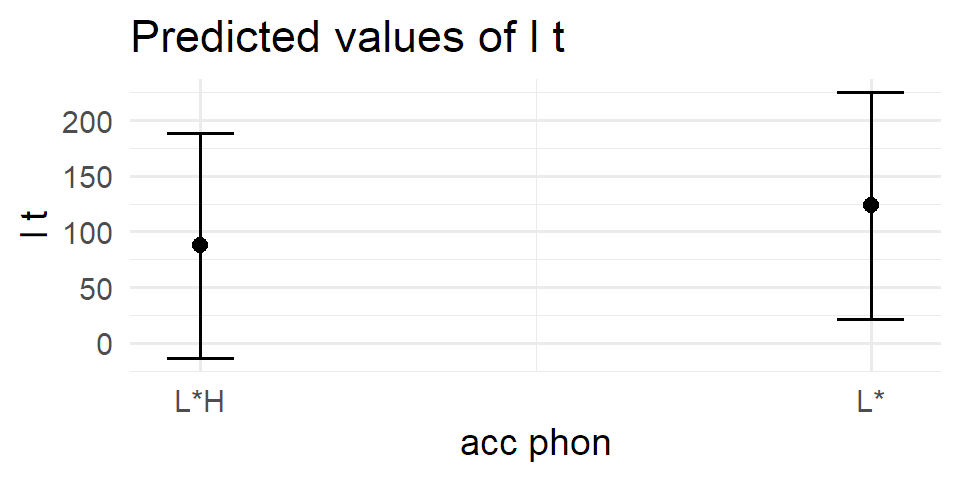

$ana_syls

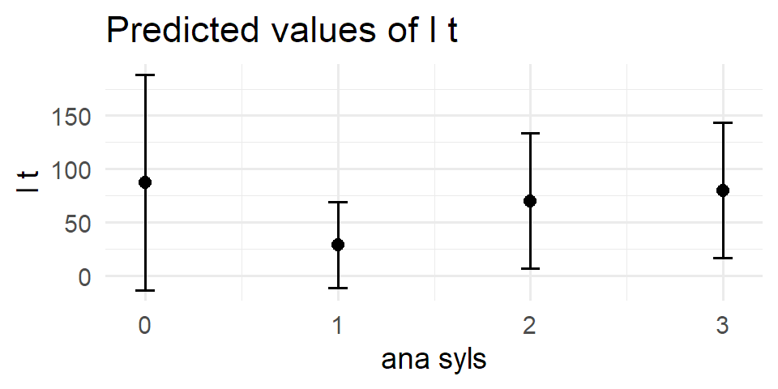

$foot_syls

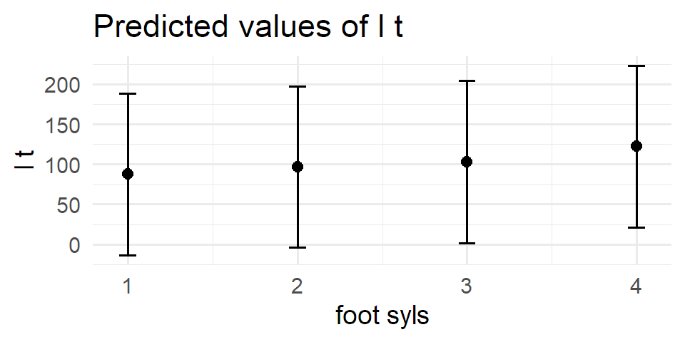

$wrd_end_syl

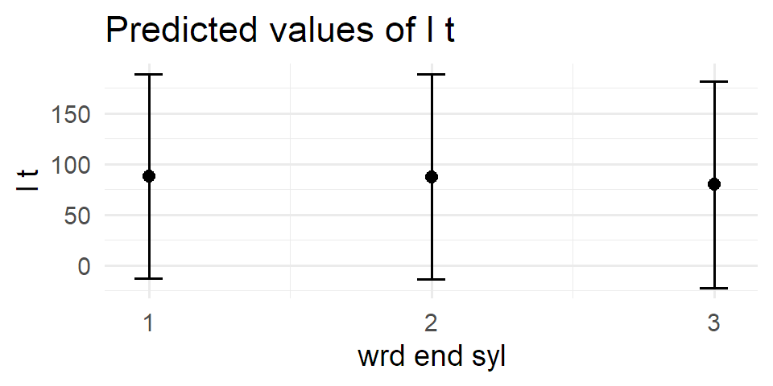

$pn_new_word

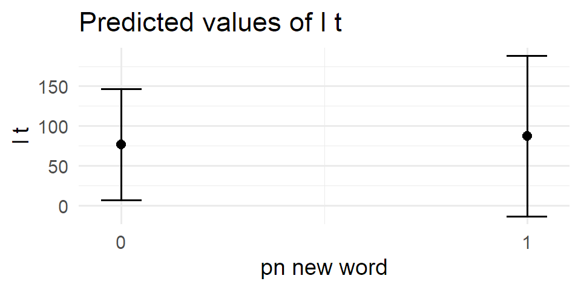

$gender

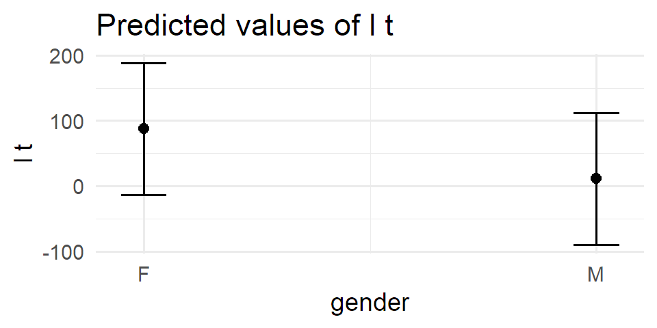

summary of model: l_t ~ acc_phon + ana_syls + foot_syls + wrd_end_syl + pn_new_word + gender + (1 | speaker) + (1 | ana_text) + (1 | ana_end_t)

| term | estimate | conf.low | conf.high | std.error | t.value | df | p.value |
| --- | --- | --- | --- | --- | --- | --- | --- |
| (Intercept) | 87.521 | -142.184031 | 317.225577 | 51.435 | 1.702 | 1.93 | 0.2357 |
| acc_phonL* | 35.779 | 15.484486 | 56.074328 | 10.324 | 3.466 | 401.36 | 6e-04 |
| ana_syls1 | -58.674 | -276.781848 | 159.433592 | 47.161 | -1.244 | 1.86 | 0.3474 |
| ana_syls2 | -17.351 | -312.899112 | 278.197400 | 60.075 | -0.289 | 1.76 | 0.8031 |
| ana_syls3 | -7.502 | -303.152927 | 288.148693 | 60.069 | -0.125 | 1.76 | 0.9134 |
| foot_syls2 | 8.922 | -3.096740 | 20.941419 | 6.114 | 1.459 | 415.36 | 0.1453 |
| foot_syls3 | 15.415 | 3.188908 | 27.640362 | 6.220 | 2.478 | 427.49 | 0.0136 |
| foot_syls4 | 34.533 | 21.000752 | 48.064319 | 6.886 | 5.015 | 462.60 | 7.6e-07 |
| wrd_end_syl2 | -0.232 | -9.076446 | 8.613207 | 4.500 | -0.051 | 439.09 | 0.959 |
| wrd_end_syl3 | -7.900 | -21.532782 | 5.732215 | 6.935 | -1.139 | 414.92 | 0.2553 |
| pn_new_word0 | -11.005 | -214.533639 | 192.524468 | 37.205 | -0.296 | 1.61 | 0.8011 |
| genderM | -76.112 | -92.881886 | -59.342754 | 7.492 | -10.160 | 9.67 | 1.8e-06 |

b0 for l_t ~ acc_phon + ana_syls + foot_syls + wrd_end_syl + pn_new_word + gender + (1 | speaker) + (1 | ana_text) + (1 | ana_end_t)

| intercept | estimate | conf.low | conf.high | std.error | t.value | df | p.value |
| --- | --- | --- | --- | --- | --- | --- | --- |
| ana_syls0 | 87.5 | -142.2 | 317.2 | 51.435 | 1.702 | 1.93 | 0.236 |
| ana_syls1 | 28.8 | -47.7 | 105.4 | 20.638 | 1.398 | 2.38 | 0.278 |
| ana_syls2 | 70.2 | -101.8 | 242.2 | 32.359 | 2.168 | 1.65 | 0.189 |
| ana_syls3 | 80 | -92.2 | 252.2 | 32.349 | 2.474 | 1.65 | 0.158 |
| foot_syls1 | 87.5 | -142.2 | 317.2 | 51.435 | 1.702 | 1.93 | 0.236 |
| foot_syls2 | 96.4 | -135.9 | 328.8 | 51.207 | 1.883 | 1.90 | 0.207 |
| foot_syls3 | 102.9 | -124.3 | 330.2 | 51.601 | 1.995 | 1.95 | 0.187 |
| foot_syls4 | 122.1 | -106.5 | 350.6 | 51.516 | 2.369 | 1.94 | 0.145 |
| wrd_end_syl1 | 87.5 | -142.2 | 317.2 | 51.435 | 1.702 | 1.93 | 0.236 |
| wrd_end_syl2 | 87.3 | -139.9 | 314.5 | 51.626 | 1.691 | 1.95 | 0.236 |
| wrd_end_syl3 | 79.6 | -144 | 303.3 | 51.895 | 1.534 | 2.00 | 0.265 |

b1 for l_t ~ acc_phon + ana_syls + foot_syls + wrd_end_syl + pn_new_word + gender + (1 | speaker) + (1 | ana_text) + (1 | ana_end_t)

| intercept | slope | estimate | conf.low | conf.high | std.error | t.value | df | p.value |
| --- | --- | --- | --- | --- | --- | --- | --- | --- |
| ana_syls0 | ana_syls1 | -58.7 | -276.8 | 159.4 | 47.161 | -1.244 | 1.86 | 0.347 |
| ana_syls0 | ana_syls2 | -17.4 | -312.9 | 278.2 | 60.075 | -0.289 | 1.76 | 0.803 |
| ana_syls0 | ana_syls3 | -7.502 | -303.2 | 288.1 | 60.069 | -0.125 | 1.76 | 0.913 |
| ana_syls1 | ana_syls2 | 41.3 | -161 | 243.6 | 37.267 | 1.109 | 1.62 | 0.405 |
| ana_syls1 | ana_syls3 | 51.2 | -151.3 | 253.7 | 37.258 | 1.373 | 1.62 | 0.329 |
| ana_syls2 | ana_syls3 | 9.849 | -259.7 | 279.4 | 44.671 | 0.220 | 1.50 | 0.852 |
| foot_syls1 | foot_syls2 | 8.922 | -3.097 | 20.9 | 6.114 | 1.459 | 415.36 | 0.145 |
| foot_syls1 | foot_syls3 | 15.4 | 3.189 | 27.6 | 6.220 | 2.478 | 427.49 | 0.014 |
| foot_syls1 | foot_syls4 | 34.5 | 21 | 48.1 | 6.886 | 5.015 | 462.60 | 7.6e-07 |
| foot_syls2 | foot_syls3 | 6.492 | -5.432 | 18.4 | 6.064 | 1.071 | 381.93 | 0.285 |
| foot_syls2 | foot_syls4 | 25.6 | 11.8 | 39.4 | 7.007 | 3.655 | 425.52 | 2.9e-04 |
| foot_syls3 | foot_syls4 | 19.1 | 9.44 | 28.8 | 4.923 | 3.884 | 385.29 | 1.2e-04 |
| wrd_end_syl1 | wrd_end_syl2 | -0.232 | -9.076 | 8.613 | 4.500 | -0.051 | 439.09 | 0.959 |
| wrd_end_syl1 | wrd_end_syl3 | -7.9 | -21.5 | 5.732 | 6.935 | -1.139 | 414.92 | 0.255 |
| wrd_end_syl2 | wrd_end_syl3 | -7.669 | -18.1 | 2.799 | 5.324 | -1.440 | 392.15 | 0.151 |
| intercept | acc_phonL* | 35.8 | 15.5 | 56.1 | 10.324 | 3.466 | 401.36 | 5.9e-04 |
| intercept | pn_new_word0 | -11 | -214.5 | 192.5 | 37.205 | -0.296 | 1.61 | 0.801 |

### Analysis of L F0

- Only intercepts only model avoided convergence and singularity issues
- Speech rate caused massive estimation issues
- Removing + wrd_end_syl as it has little effect
- removing ana_text to avoid error
- model needs trimming (|sd| residuals > 3.5)

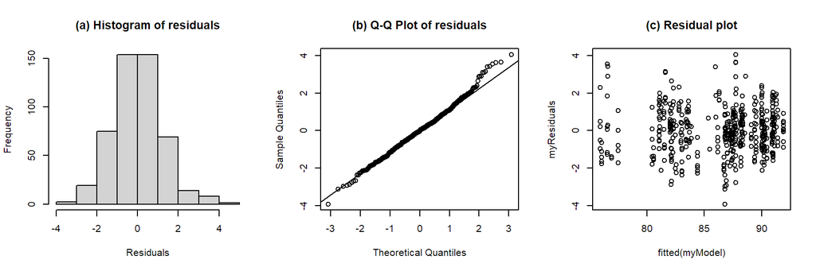

```
## Formula:  l_f0 ~ acc_phon + ana_syls + foot_syls + pn_new_word + (1 | speaker)
##
## Linear mixed model fit by REML. t-tests use Satterthwaite's method [
## lmerModLmerTest]
## Formula: l_f0_equation
##    Data: pn_l_f0.trimmed
## Control:
## lmerControl(optimizer = optimizer, calc.derivs = FALSE, optCtrl = list(method = "nlminb",
##     starttests = FALSE, kkt = FALSE))
##
## REML criterion at convergence: 1678.8
##
## Scaled residuals:
##     Min      1Q  Median      3Q     Max
## -3.1928 -0.6494 -0.0184  0.5965  3.2955
##
## Random effects:
##  Groups   Name        Variance Std.Dev.
##  speaker  (Intercept) 19.888   4.460
##  Residual              1.505   1.227
## Number of obs: 496, groups:  speaker, 11
##
## Fixed effects:
##               Estimate Std. Error        df t value Pr(>|t|)
## (Intercept)   85.22809    1.37289  10.82034  62.079 3.66e-15 ***
## acc_phonL*    -0.15468    0.45415 477.16803  -0.341  0.73357
## ana_syls1      0.90681    0.19123 477.02023   4.742 2.80e-06 ***
## ana_syls2      0.23031    0.30196 477.03046   0.763  0.44601
## ana_syls3      0.09203    0.30295 477.03118   0.304  0.76142
## foot_syls2    -0.09613    0.24478 477.03902  -0.393  0.69469
## foot_syls3    -0.20057    0.24372 477.05815  -0.823  0.41095
## foot_syls4    -0.26494    0.21292 477.05700  -1.244  0.21400
## pn_new_word0   0.70339    0.25651 477.02570   2.742  0.00633 **
## ---
## Signif. codes:  0 '***' 0.001 '**' 0.01 '*' 0.05 '.' 0.1 ' ' 1
##
## Correlation of Fixed Effects:
##             (Intr) acc_L* an_sy1 an_sy2 an_sy3 ft_sy2 ft_sy3 ft_sy4
## acc_phonL*  -0.023
## ana_syls1   -0.139 -0.020
```

[output cut: 17 more lines]

```
## Backward reduced fixed-effect table:
## Degrees of freedom method: Satterthwaite
##
##             Eliminated Sum Sq Mean Sq NumDF  DenDF F value    Pr(>F)
## acc_phon             1  0.175  0.1745     1 477.17   0.116 0.7335696
## foot_syls            2  2.415  0.8049     3 478.04   0.536 0.6578418
## ana_syls             0 84.909 28.3030     3 481.04  18.901 1.328e-11 ***
## pn_new_word          0 18.448 18.4478     1 481.06  12.319 0.0004904 ***
## ---
## Signif. codes:  0 '***' 0.001 '**' 0.01 '*' 0.05 '.' 0.1 ' ' 1
##
## Model found:
## l_f0 ~ ana_syls + pn_new_word + (1 | speaker)
##
## isSingular(my_model, tol = 1e-05 ) --> FALSE
```

Anova of model: l_f0 ~ acc_phon + ana_syls + foot_syls + pn_new_word + (1 | speaker)

| term | sumsq | meansq | NumDF | DenDF | F value | p.value | signif. |
| --- | --- | --- | --- | --- | --- | --- | --- |
| acc_phon | 0.175 | 0.175 | 1 | 477.168 | 0.116 | 7.335696e-01 |  |
| ana_syls | 55.319 | 18.440 | 3 | 477.022 | 12.255 | 9.762219e-08 | p<0.001 |
| foot_syls | 2.589 | 0.863 | 3 | 477.046 | 0.574 | 6.326556e-01 |  |
| pn_new_word | 11.314 | 11.314 | 1 | 477.026 | 7.519 | 6.333472e-03 | p<0.01 |

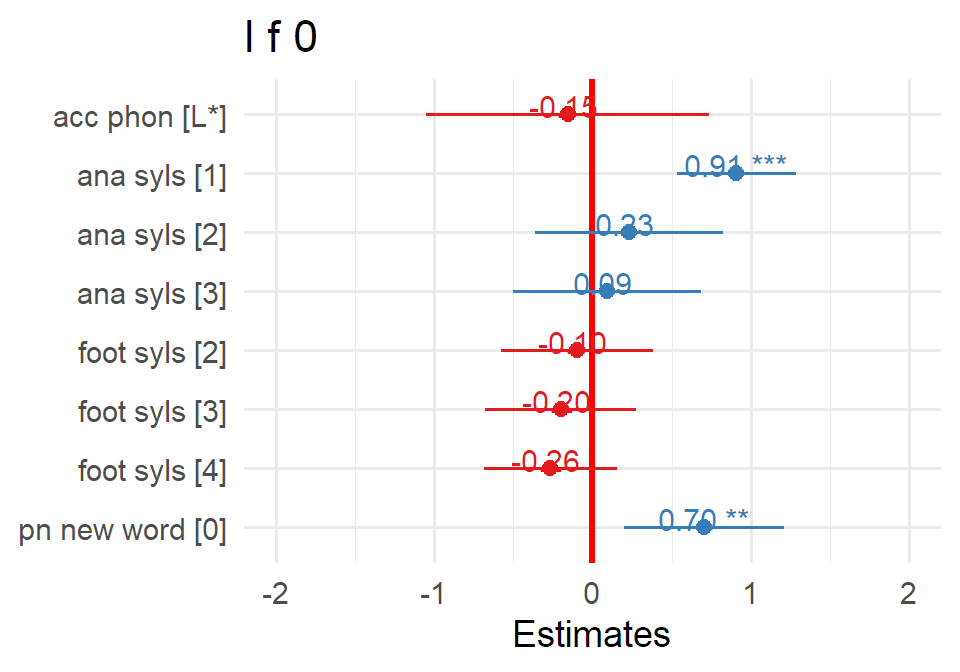

Conditional and marginal R<sup>2</sup> of model

| R2_conditional | R2_marginal |
| --- | --- |
| 0.93 | 0.01 |

$acc_phon

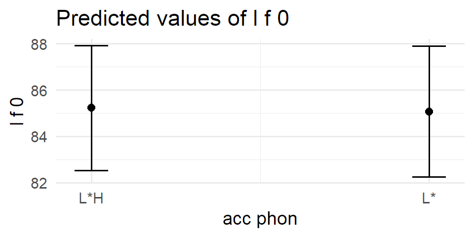

$ana_syls

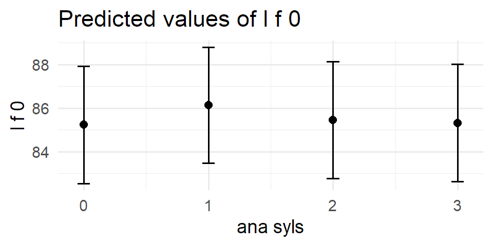

$foot_syls

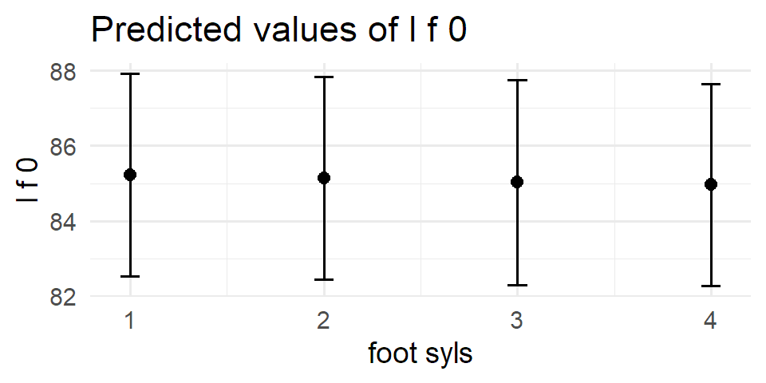

$pn_new_word

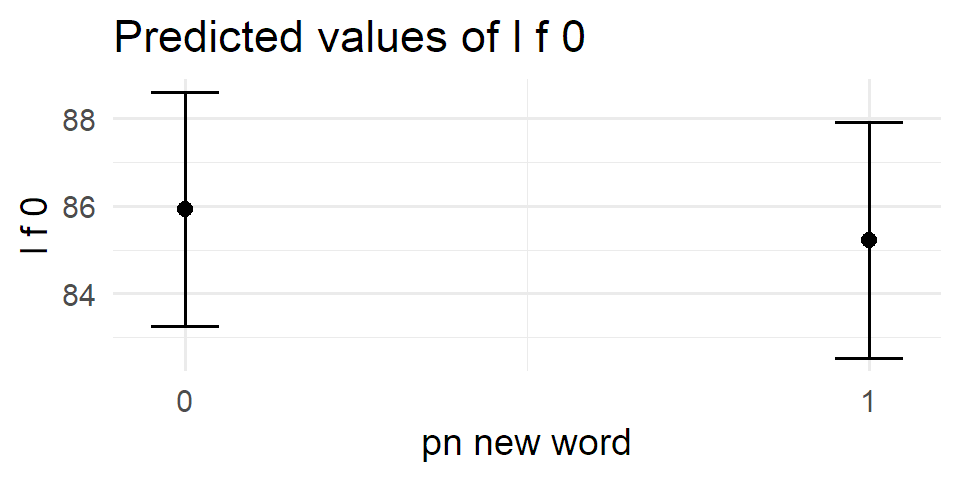

summary of model: l_f0 ~ acc_phon + ana_syls + foot_syls + pn_new_word + (1 | speaker)

| term | estimate | conf.low | conf.high | std.error | t.value | df | p.value |
| --- | --- | --- | --- | --- | --- | --- | --- |
| (Intercept) | 85.228 | 82.2002543 | 88.2559285 | 1.373 | 62.079 | 10.82 | 3.7e-15 |
| acc_phonL* | -0.155 | -1.0470614 | 0.7377107 | 0.454 | -0.341 | 477.17 | 0.7336 |
| ana_syls1 | 0.907 | 0.5310526 | 1.2825624 | 0.191 | 4.742 | 477.02 | 2.8e-06 |
| ana_syls2 | 0.230 | -0.3630266 | 0.8236476 | 0.302 | 0.763 | 477.03 | 0.446 |
| ana_syls3 | 0.092 | -0.5032399 | 0.6873035 | 0.303 | 0.304 | 477.03 | 0.7614 |
| foot_syls2 | -0.096 | -0.5771133 | 0.3848474 | 0.245 | -0.393 | 477.04 | 0.6947 |
| foot_syls3 | -0.201 | -0.6794746 | 0.2783352 | 0.244 | -0.823 | 477.06 | 0.411 |
| foot_syls4 | -0.265 | -0.6833199 | 0.1534448 | 0.213 | -1.244 | 477.06 | 0.214 |
| pn_new_word0 | 0.703 | 0.1993594 | 1.2074264 | 0.257 | 2.742 | 477.03 | 0.0063 |

b0 for l_f0 ~ acc_phon + ana_syls + foot_syls + pn_new_word + (1 | speaker)

| intercept | estimate | conf.low | conf.high | std.error | t.value | df | p.value |
| --- | --- | --- | --- | --- | --- | --- | --- |
| ana_syls0 | 85.2 | 82.2 | 88.3 | 1.373 | 62.079 | 10.82 | 3.7e-15 |
| ana_syls1 | 86.1 | 83.1 | 89.1 | 1.359 | 63.359 | 10.40 | 8.4e-15 |
| ana_syls2 | 85.5 | 82.4 | 88.5 | 1.372 | 62.269 | 10.81 | 3.7e-15 |
| ana_syls3 | 85.3 | 82.3 | 88.3 | 1.373 | 62.159 | 10.81 | 3.7e-15 |
| foot_syls1 | 85.2 | 82.2 | 88.3 | 1.373 | 62.079 | 10.82 | 3.7e-15 |
| foot_syls2 | 85.1 | 82.1 | 88.2 | 1.374 | 61.949 | 10.86 | 3.4e-15 |
| foot_syls3 | 85 | 82 | 88.1 | 1.390 | 61.167 | 11.37 | 1.1e-15 |
| foot_syls4 | 85 | 81.9 | 88 | 1.368 | 62.102 | 10.67 | 5.3e-15 |

b1 for l_f0 ~ acc_phon + ana_syls + foot_syls + pn_new_word + (1 | speaker)

| intercept | slope | estimate | conf.low | conf.high | std.error | t.value | df | p.value |
| --- | --- | --- | --- | --- | --- | --- | --- | --- |
| ana_syls0 | ana_syls1 | 0.907 | 0.531 | 1.283 | 0.191 | 4.742 | 477.02 | 2.8e-06 |
| ana_syls0 | ana_syls2 | 0.23 | -0.363 | 0.824 | 0.302 | 0.763 | 477.03 | 0.446 |
| ana_syls0 | ana_syls3 | 0.092 | -0.503 | 0.687 | 0.303 | 0.304 | 477.03 | 0.761 |
| ana_syls1 | ana_syls2 | -0.676 | -1.135 | -0.218 | 0.233 | -2.901 | 477.03 | 0.004 |
| ana_syls1 | ana_syls3 | -0.815 | -1.276 | -0.354 | 0.234 | -3.475 | 477.03 | 5.6e-04 |
| ana_syls2 | ana_syls3 | -0.138 | -0.613 | 0.337 | 0.242 | -0.572 | 477.01 | 0.568 |
| foot_syls1 | foot_syls2 | -0.096 | -0.577 | 0.385 | 0.245 | -0.393 | 477.04 | 0.695 |
| foot_syls1 | foot_syls3 | -0.201 | -0.679 | 0.278 | 0.244 | -0.823 | 477.06 | 0.411 |
| foot_syls1 | foot_syls4 | -0.265 | -0.683 | 0.153 | 0.213 | -1.244 | 477.06 | 0.214 |
| foot_syls2 | foot_syls3 | -0.104 | -0.57 | 0.361 | 0.237 | -0.441 | 477.04 | 0.66 |
| foot_syls2 | foot_syls4 | -0.169 | -0.583 | 0.245 | 0.211 | -0.801 | 477.05 | 0.424 |
| foot_syls3 | foot_syls4 | -0.064 | -0.429 | 0.3 | 0.185 | -0.347 | 477.03 | 0.729 |
| intercept | acc_phonL* | -0.155 | -1.047 | 0.738 | 0.454 | -0.341 | 477.17 | 0.734 |
| intercept | pn_new_word0 | 0.703 | 0.199 | 1.207 | 0.257 | 2.742 | 477.03 | 0.006 |

## Truncation and Compression Effects

Based on results from tonal target analysis, it looks there is an element of truncation in LH contours as a function of foot size, alongside a degree of rightward drift in L targets as foot size increases. However, superficially, it looks like the slope is stable.

As with nuclear data, I am retaining the overall model structure as much as possible BUT will discard all but foot_syls for analysis.